# Macroeconomic Trend Analysis

Inflation, Unemployment & GDP | R + SQL Pipeline

Author

Noah Hebert

Published

March 4, 2026

## Project Overview

This project builds a macroeconomic analysis pipeline using R and SQL to model an 11-month disinflation cycle (April 2025 – February 2026). A synthetic dataset was constructed to reflect plausible Federal Reserve policy responses — gradual rate reductions from 5.50% to 4.25% in response to declining inflation, with lagged effects on GDP growth, unemployment, and consumer sentiment.

The workflow covers the full analysis lifecycle: data ingestion, tidyverse wrangling, ggplot2 visualization, and SQLite-based aggregation using window functions and conditional signal classification — replicating the kind of pipeline used in economic research and financial analysis roles.

## Setup

```r
library(readr)
library(dplyr)
library(tidyr)
library(ggplot2)
library(DBI)
library(RSQLite)
library(knitr)
```

## Dataset

The dataset models six macroeconomic indicators across 11 months. Variables were designed to reflect a realistic soft-landing scenario: inflation declining toward a 2% target while unemployment rises modestly and GDP decelerates.

```r
econ_data <- read_csv(I(
"month,inflation_rate,unemployment_rate,gdp_growth,consumer_sentiment,interest_rate,retail_sales_growth
2025-04,3.8,4.0,2.4,71,5.50,2.1
2025-05,3.7,4.0,2.3,72,5.50,2.0
2025-06,3.5,4.1,2.2,73,5.25,1.9
2025-07,3.4,4.1,2.1,74,5.25,1.8
2025-08,3.3,4.2,2.0,75,5.00,1.7
2025-09,3.2,4.2,1.9,76,5.00,1.6
2025-10,3.1,4.3,1.8,77,4.75,1.5
2025-11,3.0,4.3,1.8,78,4.75,1.4
2025-12,2.9,4.4,1.7,79,4.50,1.3
2026-01,2.8,4.4,1.6,80,4.50,1.2
2026-02,2.7,4.5,1.5,81,4.25,1.1"
)) %>%
  mutate(month = as.Date(paste0(month, "-01")))

kable(econ_data, caption = "Table 1: Full Macroeconomic Dataset (Apr 2025 – Feb 2026)")
```

Table 1: Full Macroeconomic Dataset (Apr 2025 – Feb 2026)

| month | inflation_rate | unemployment_rate | gdp_growth | consumer_sentiment | interest_rate | retail_sales_growth |
| --- | --- | --- | --- | --- | --- | --- |
| 2025-04-01 | 3.8 | 4.0 | 2.4 | 71 | 5.50 | 2.1 |
| 2025-05-01 | 3.7 | 4.0 | 2.3 | 72 | 5.50 | 2.0 |
| 2025-06-01 | 3.5 | 4.1 | 2.2 | 73 | 5.25 | 1.9 |
| 2025-07-01 | 3.4 | 4.1 | 2.1 | 74 | 5.25 | 1.8 |
| 2025-08-01 | 3.3 | 4.2 | 2.0 | 75 | 5.00 | 1.7 |
| 2025-09-01 | 3.2 | 4.2 | 1.9 | 76 | 5.00 | 1.6 |
| 2025-10-01 | 3.1 | 4.3 | 1.8 | 77 | 4.75 | 1.5 |
| 2025-11-01 | 3.0 | 4.3 | 1.8 | 78 | 4.75 | 1.4 |
| 2025-12-01 | 2.9 | 4.4 | 1.7 | 79 | 4.50 | 1.3 |
| 2026-01-01 | 2.8 | 4.4 | 1.6 | 80 | 4.50 | 1.2 |
| 2026-02-01 | 2.7 | 4.5 | 1.5 | 81 | 4.25 | 1.1 |

## Visualizations

### Inflation vs. Unemployment Rate

Both series were reshaped to long format using `pivot_longer()` before plotting. The inverse relationship between disinflation and rising unemployment is consistent with the expectations-augmented Phillips Curve.

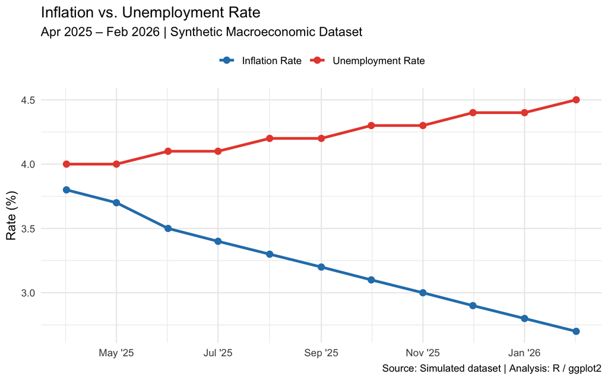

Figure 1: Inflation declined 1.1 pp as unemployment rose 0.5 pp — consistent with a soft-landing disinflation scenario.

```r
plot_data <- econ_data %>%
  select(month, inflation_rate, unemployment_rate) %>%
  pivot_longer(
    cols = c(inflation_rate, unemployment_rate),
    names_to = "metric",
    values_to = "value"
  )

ggplot(plot_data, aes(x = month, y = value, color = metric)) +
  geom_line(linewidth = 1.2) +
  geom_point(size = 2.5) +
  scale_color_manual(
    values = c("inflation_rate" = "#2980B9", "unemployment_rate" = "#E74C3C"),
    labels = c("Inflation Rate", "Unemployment Rate")
  ) +
  scale_x_date(date_labels = "%b '%y", date_breaks = "2 months") +
  labs(
    title    = "Inflation vs. Unemployment Rate",
    subtitle = "Apr 2025 – Feb 2026 | Synthetic Macroeconomic Dataset",
    x = NULL, y = "Rate (%)", color = NULL,
    caption  = "Source: Simulated dataset | Analysis: R / ggplot2"
  ) +
  theme_minimal(base_size = 12) +
  theme(legend.position = "top")
```

### GDP Growth vs. Retail Sales Growth

A line chart comparing GDP growth against retail sales growth to assess whether consumer spending aligned with output deceleration. Retail sales contracted faster than GDP — signaling weakening demand ahead of output.

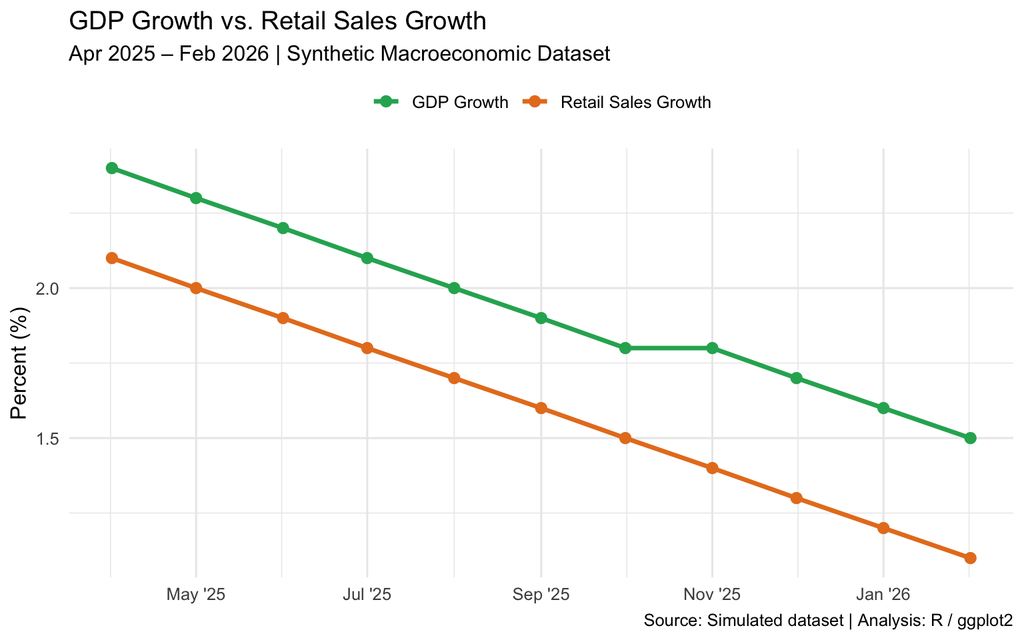

Figure 2: Retail sales contracted faster than GDP across the period, signaling demand weakness leading output deceleration.

```r
gdp_data <- econ_data %>%
  select(month, gdp_growth, retail_sales_growth) %>%
  pivot_longer(
    cols = c(gdp_growth, retail_sales_growth),
    names_to = "metric",
    values_to = "value"
  )

ggplot(gdp_data, aes(x = month, y = value, color = metric)) +
  geom_line(linewidth = 1.2) +
  geom_point(size = 2.5) +
  scale_color_manual(
    values = c("gdp_growth" = "#27AE60", "retail_sales_growth" = "#E67E22"),
    labels = c("GDP Growth", "Retail Sales Growth")
  ) +
  scale_x_date(date_labels = "%b '%y", date_breaks = "2 months") +
  labs(
    title    = "GDP Growth vs. Retail Sales Growth",
    subtitle = "Apr 2025 – Feb 2026 | Synthetic Macroeconomic Dataset",
    x = NULL, y = "Percent (%)", color = NULL,
    caption  = "Source: Simulated dataset | Analysis: R / ggplot2"
  ) +
  theme_minimal(base_size = 12) +
  theme(legend.position = "top")
```

## SQL Analysis

The dataset was loaded into an in-memory SQLite database via the `DBI` and `RSQLite` packages. Months are stored as character strings (`YYYY-MM-DD`) to avoid SQLite’s Unix day-integer conversion, which would otherwise render dates as raw integers in query output.

```r
con <- dbConnect(RSQLite::SQLite(), ":memory:")

dbWriteTable(
  con,
  "economic_indicators",
  econ_data %>% mutate(month = as.character(month)),
  overwrite = TRUE
)
```

### Query 1 — 3-Month Rolling Averages

`AVG() OVER (ROWS BETWEEN 2 PRECEDING AND CURRENT ROW)` computes a trailing 3-month average for inflation and unemployment, smoothing short-term noise to reveal the underlying trend direction.

```r
rolling_avg <- dbGetQuery(con, "
SELECT
  month,
  inflation_rate,
  ROUND(AVG(inflation_rate) OVER (
    ORDER BY month
    ROWS BETWEEN 2 PRECEDING AND CURRENT ROW
  ), 3) AS inflation_3m_avg,
  unemployment_rate,
  ROUND(AVG(unemployment_rate) OVER (
    ORDER BY month
    ROWS BETWEEN 2 PRECEDING AND CURRENT ROW
  ), 3) AS unemployment_3m_avg
FROM economic_indicators
")

kable(rolling_avg, caption = "Table 2: 3-Month Rolling Averages — Inflation & Unemployment")
```

Table 2: 3-Month Rolling Averages — Inflation & Unemployment

| month | inflation_rate | inflation_3m_avg | unemployment_rate | unemployment_3m_avg |
| --- | --- | --- | --- | --- |
| 2025-04-01 | 3.8 | 3.800 | 4.0 | 4.000 |
| 2025-05-01 | 3.7 | 3.750 | 4.0 | 4.000 |
| 2025-06-01 | 3.5 | 3.667 | 4.1 | 4.033 |
| 2025-07-01 | 3.4 | 3.533 | 4.1 | 4.067 |
| 2025-08-01 | 3.3 | 3.400 | 4.2 | 4.133 |
| 2025-09-01 | 3.2 | 3.300 | 4.2 | 4.167 |
| 2025-10-01 | 3.1 | 3.200 | 4.3 | 4.233 |
| 2025-11-01 | 3.0 | 3.100 | 4.3 | 4.267 |
| 2025-12-01 | 2.9 | 3.000 | 4.4 | 4.333 |
| 2026-01-01 | 2.8 | 2.900 | 4.4 | 4.367 |
| 2026-02-01 | 2.7 | 2.800 | 4.5 | 4.433 |

### Query 2 — Macro Signal Classification

A `CASE WHEN` statement classifies each month into one of three macro regimes based on GDP, retail sales, inflation, and interest rate thresholds — mirroring rule-based signal labeling used in economic policy dashboards.

```r
macro_signal <- dbGetQuery(con, "
SELECT
  month,
  inflation_rate,
  interest_rate,
  gdp_growth,
  retail_sales_growth,
  CASE
    WHEN gdp_growth < 1.8 AND retail_sales_growth < 1.3 THEN 'Demand Softening'
    WHEN inflation_rate > 3.5 AND interest_rate > 5.0   THEN 'High Inflation / Tight Policy'
    ELSE 'Stable'
  END AS macro_signal
FROM economic_indicators
")

kable(macro_signal, caption = "Table 3: Macro Regime Classification by Month")
```

Table 3: Macro Regime Classification by Month

| month | inflation_rate | interest_rate | gdp_growth | retail_sales_growth | macro_signal |
| --- | --- | --- | --- | --- | --- |
| 2025-04-01 | 3.8 | 5.50 | 2.4 | 2.1 | High Inflation / Tight Policy |
| 2025-05-01 | 3.7 | 5.50 | 2.3 | 2.0 | High Inflation / Tight Policy |
| 2025-06-01 | 3.5 | 5.25 | 2.2 | 1.9 | Stable |
| 2025-07-01 | 3.4 | 5.25 | 2.1 | 1.8 | Stable |
| 2025-08-01 | 3.3 | 5.00 | 2.0 | 1.7 | Stable |
| 2025-09-01 | 3.2 | 5.00 | 1.9 | 1.6 | Stable |
| 2025-10-01 | 3.1 | 4.75 | 1.8 | 1.5 | Stable |
| 2025-11-01 | 3.0 | 4.75 | 1.8 | 1.4 | Stable |
| 2025-12-01 | 2.9 | 4.50 | 1.7 | 1.3 | Stable |
| 2026-01-01 | 2.8 | 4.50 | 1.6 | 1.2 | Demand Softening |
| 2026-02-01 | 2.7 | 4.25 | 1.5 | 1.1 | Demand Softening |

### Query 3 — Month-over-Month Change

`LAG()` computes period-over-period deltas for inflation, unemployment, and GDP — quantifying the pace and direction of change across all key indicators.

```r
mom_change <- dbGetQuery(con, "
SELECT
  month,
  inflation_rate,
  ROUND(inflation_rate - LAG(inflation_rate) OVER (ORDER BY month), 2) AS inflation_change,
  unemployment_rate,
  ROUND(unemployment_rate - LAG(unemployment_rate) OVER (ORDER BY month), 2) AS unemployment_change,
  gdp_growth,
  ROUND(gdp_growth - LAG(gdp_growth) OVER (ORDER BY month), 2) AS gdp_change
FROM economic_indicators
")

kable(mom_change, caption = "Table 4: Month-over-Month Change — Key Indicators")
```

Table 4: Month-over-Month Change — Key Indicators

| month | inflation_rate | inflation_change | unemployment_rate | unemployment_change | gdp_growth | gdp_change |
| --- | --- | --- | --- | --- | --- | --- |
| 2025-04-01 | 3.8 | NA | 4.0 | NA | 2.4 | NA |
| 2025-05-01 | 3.7 | -0.1 | 4.0 | 0.0 | 2.3 | -0.1 |
| 2025-06-01 | 3.5 | -0.2 | 4.1 | 0.1 | 2.2 | -0.1 |
| 2025-07-01 | 3.4 | -0.1 | 4.1 | 0.0 | 2.1 | -0.1 |
| 2025-08-01 | 3.3 | -0.1 | 4.2 | 0.1 | 2.0 | -0.1 |
| 2025-09-01 | 3.2 | -0.1 | 4.2 | 0.0 | 1.9 | -0.1 |
| 2025-10-01 | 3.1 | -0.1 | 4.3 | 0.1 | 1.8 | -0.1 |
| 2025-11-01 | 3.0 | -0.1 | 4.3 | 0.0 | 1.8 | 0.0 |
| 2025-12-01 | 2.9 | -0.1 | 4.4 | 0.1 | 1.7 | -0.1 |
| 2026-01-01 | 2.8 | -0.1 | 4.4 | 0.0 | 1.6 | -0.1 |
| 2026-02-01 | 2.7 | -0.1 | 4.5 | 0.1 | 1.5 | -0.1 |

### Query 4 — Pearson Correlation (Inflation vs. Unemployment)

Manual computation of the Pearson correlation coefficient between inflation and unemployment directly in SQL — no R post-processing required. A negative result confirms the inverse Phillips Curve relationship present in the data.

```r
corr_result <- dbGetQuery(con, "
SELECT
  ROUND(
    (AVG(inflation_rate * unemployment_rate) - AVG(inflation_rate) * AVG(unemployment_rate))
    /
    (SQRT(AVG(inflation_rate * inflation_rate) - AVG(inflation_rate) * AVG(inflation_rate))
     * SQRT(AVG(unemployment_rate * unemployment_rate) - AVG(unemployment_rate) * AVG(unemployment_rate))),
  4) AS pearson_corr_infl_unemp
FROM economic_indicators
")

kable(corr_result, caption = "Table 5: Pearson Correlation — Inflation vs. Unemployment")
```

Table 5: Pearson Correlation — Inflation vs. Unemployment

| pearson_corr_infl_unemp |
| --- |
| -0.9851 |

## Key Findings

| Metric | Change | Interpretation |
| --- | --- | --- |
| Inflation | -1.1 pp | Sustained disinflation toward 2% target |
| Unemployment | +0.5 pp | Modest labor market softening; soft-landing dynamic |
| GDP Growth | -0.9 pp | Steady deceleration; demand-side weakness in final months |
| Rate Cuts Modeled | 125 bps | 5 cuts of 25 bps across the easing cycle |
| Infl/Unemp Correlation | -0.9851 | Negative — Phillips Curve relationship confirmed |

**Soft-landing signal:** Inflation fell meaningfully while unemployment rose only modestly (+0.5 pp), consistent with a controlled disinflation scenario rather than a recession-driven correction. The final two months were classified as *Demand Softening* by the SQL signal logic, suggesting the economy was approaching — but had not yet entered — a contractionary phase.

*Built with R · ggplot2 · dplyr · SQLite · Quarto*